# Daily Turkish Financial Volatility Index

2020-11-19

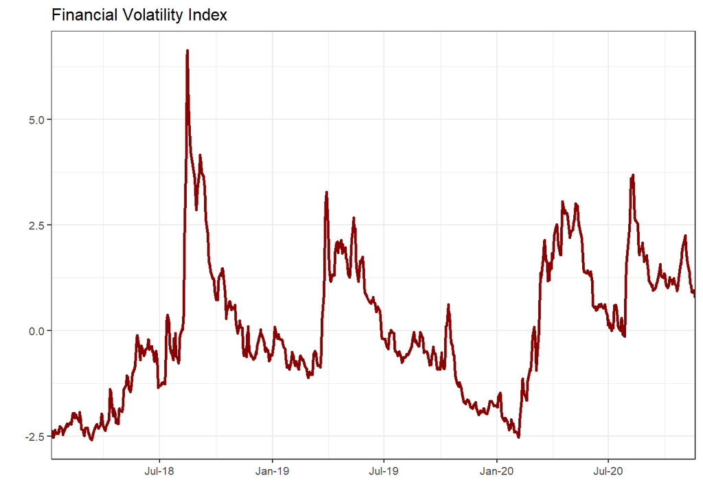

This index tracks the volatility and risk in the Turkish financial markets. Five variables that can be used the track financial vlatility and risk in Turkey are selected for this index:

1. USD/TRY 3-Months Implied Volatility,
2. USD/TRY 3-Months Risk Reversal Skew,
3. Turkish 5 Year CDS,
4. BIST 100 Volatility[^1],
5. 2-Years Turkish Benchmark Interest Rate Volatility[^2].

All variables are standardized and smoothed using 3-days moving average. The weight of each variable in the index is obtained using principal component analysis.

The index data can be downloaded here

[interactive chart not shown]

Here is the code in to produce the above plotly figure (will appear in a minute):

```r
library("plotly") #animated graph
library("widgetframe") #frame package

index <- read.csv("https://www.soybilgen.com/files/TRYFCIindex.csv", stringsAsFactors = F)
index$Date <- as.Date(index$Date, "%Y-%m-%d")

fig <- plot_ly(index, x = ~Date)
fig <- fig %>% add_trace(y = ~FCI, name = 'Financial Volatility Index',type = 'scatter', mode = 'lines',color = I('black'))
fig <- fig %>% add_trace(y = ~FX_Implied_Vol, name = 'TRY Implied Volatility', type = 'scatter', mode = "lines",
                         line = list(color = 'rgb(188, 189, 34)', width = 2, dash = 'solid', shape= "linear"),
                         fill = 'tozeroy', fillcolor='rgba(188, 189, 34, 0.5)',hoveron = 'points')
fig <- fig %>% add_trace(y = ~FX_25_Delta_Rate, name = 'TRY 25 Delta Rate', type = 'scatter', mode = "lines",
                         line = list(color = 'rgb(127, 127, 127)', width = 2, dash = 'solid', shape= "linear"),
                         fill = 'tozeroy', fillcolor='rgba(127, 127, 127, 0.5)',hoveron = 'points')
fig <- fig %>% add_trace(y = ~CDS, name = 'CDS', type = 'scatter', mode = "lines",
                         line = list(color = 'rgb(214, 39, 40)', width = 2, dash = 'solid', shape= "linear"),
                         fill = 'tozeroy', fillcolor='rgba(214, 39, 40, 0.5)',hoveron = 'points')
fig <- fig %>% add_trace(y = ~BIST100_Vol, name = 'BIST 100 Volatility', type = 'scatter', mode = "lines",
                         line = list(color = 'rgb(255, 199, 38)', width = 2, dash = 'solid', shape= "linear"),
                         fill = 'tozeroy', fillcolor='rgba(255, 199, 38, 0.5)',hoveron = 'points')
fig <- fig %>% add_trace(y = ~Benchmark_Rate_Vol, name = 'Interest Rate Volatility', type = 'scatter', mode = "lines",
                         line = list(color = 'rgb(87, 65, 47)', width = 2, dash = 'solid', shape= "linear"),
                         fill = 'tozeroy', fillcolor='rgba(87, 65, 47, 0.5)',hoveron = 'points')
fig <- fig %>% rangeslider()
fig <- fig %>% layout(xaxis = list(title = ""))
fig <- fig %>% layout(yaxis = list(title = ""))
fig <- fig %>% layout(legend = list(orientation = 'h'))
fig <- fig %>% layout(legend = list(x = 0, y = -0.5))
fig <- fig %>% layout(title = "<b>Financial Volatility Index</b>")

frameWidget(fig)
```

[^1]: The difference between Open Price of BIST 100 at time $t$ and Lowest Price of BIST 100 at time $t$ divided by Open Price of BIST 100 at time $t$.
[^2]: the difference between Open Price of 2-Years Turkish Benchmark Interest Rate at time $t$ and Highest Price of 2-Years Turkish Benchmark Interest Rate at time $t$ divided by Open Price of 2-Years Turkish Benchmark Interest Rate at time $t$.